# Permutation for Regression

Alex Damisch

August 28, 2015

## Getting Started

We will examine the `HappyPlanetIndex` data set, found in the `Lock5Data` package. We will also need the `ggplot2` package for graphics, and the `mosaic` package for some data manipulation functions.

```r
library(Lock5Data)
data(HappyPlanetIndex)
library(ggplot2)
library(mosaic)
```

This data set contains different measurements of happiness and well-being for 143 countries.

```r
head(HappyPlanetIndex)
```

```
##     Country Region Happiness LifeExpectancy Footprint  HLY   HPI HPIRank
## 1   Albania      7       5.5           76.2       2.2 41.7 47.91      54
## 2   Algeria      3       5.6           71.7       1.7 40.1 51.23      40
## 3    Angola      4       4.3           41.7       0.9 17.8 26.78     130
## 4 Argentina      1       7.1           74.8       2.5 53.4 58.95      15
## 5   Armenia      7       5.0           71.7       1.4 36.1 48.28      48
## 6 Australia      2       7.9           80.9       7.8 63.7 36.64     102
##   GDPperCapita   HDI Population
## 1         5316 0.801       3.15
## 2         7062 0.733      32.85
## 3         2335 0.446      16.10
## 4        14280 0.869      38.75
## 5         4945 0.775       3.02
## 6        31794 0.962      20.40
```

```r
summary(HappyPlanetIndex)
```

```
##       Country        Region        Happiness     LifeExpectancy
##  Albania  :  1   Min.   :1.000   Min.   :2.400   Min.   :40.50
##  Algeria  :  1   1st Qu.:2.000   1st Qu.:5.000   1st Qu.:61.90
##  Angola   :  1   Median :4.000   Median :5.900   Median :71.50
##  Argentina:  1   Mean   :3.832   Mean   :5.919   Mean   :67.84
##  Armenia  :  1   3rd Qu.:6.000   3rd Qu.:7.000   3rd Qu.:76.05
##  Australia:  1   Max.   :7.000   Max.   :8.500   Max.   :82.30
##  (Other)  :137
##    Footprint           HLY             HPI           HPIRank
##  Min.   : 0.500   Min.   :11.60   Min.   :16.59   Min.   :  1.0
##  1st Qu.: 1.300   1st Qu.:31.10   1st Qu.:34.47   1st Qu.: 36.5
##  Median : 2.200   Median :41.80   Median :43.60   Median : 72.0
##  Mean   : 2.877   Mean   :41.38   Mean   :43.38   Mean   : 72.0
##  3rd Qu.: 3.850   3rd Qu.:53.20   3rd Qu.:52.20   3rd Qu.:107.5
##  Max.   :10.200   Max.   :66.70   Max.   :76.12   Max.   :143.0
##
##   GDPperCapita        HDI           Population
##  Min.   :  667   Min.   :0.3360   Min.   :   0.290
##  1st Qu.: 2107   1st Qu.:0.5790   1st Qu.:   4.455
##  Median : 6632   Median :0.7720   Median :  10.480
##  Mean   :11275   Mean   :0.7291   Mean   :  44.145
##  3rd Qu.:15711   3rd Qu.:0.8680   3rd Qu.:  31.225
##  Max.   :60228   Max.   :0.9680   Max.   :1304.500
##  NA's   :2       NA's   :2
```

We will choose `Happiness` as our response variable, to see how different measurements of quality of life in a country affect `Happiness`.

Optionally, you can remove the rows with missing values.

```r
HappyPlanetIndex <- HappyPlanetIndex[-63, -113]
```

Assuming you already know the basics of linear models (see Basics of Linear Models guide), we will make a correlation matrix for the data set, excluding the first variable. If you did not choose to remove the rows with missing values, you will need the `use` argument; if you did, you don’t need it.

```r
cor(HappyPlanetIndex[-1], use="complete.obs")
```

```
##                     Region   Happiness LifeExpectancy   Footprint
## Region          1.00000000 -0.39403612    -0.18329022 -0.19614183
## Happiness      -0.39403612  1.00000000     0.83342784  0.64329499
## LifeExpectancy -0.18329022  0.83342784     1.00000000  0.62661887
## Footprint      -0.19614183  0.64329499     0.62661887  1.00000000
## HLY            -0.35715858  0.97482271     0.92457559  0.69236646
## HPI            -0.23185284  0.59024399     0.54409200 -0.18107454
## HPIRank         0.22555826 -0.55519491    -0.52064898  0.21120155
## GDPperCapita   -0.24143178  0.69768299     0.66620716  0.88482249
## HDI            -0.14590423  0.83559974     0.92656383  0.73675814
## Population      0.09973282  0.04256389     0.01391005 -0.06962928
##                        HLY         HPI     HPIRank GDPperCapita
## Region         -0.35715858 -0.23185284  0.22555826  -0.24143178
## Happiness       0.97482271  0.59024399 -0.55519491   0.69768299
## LifeExpectancy  0.92457559  0.54409200 -0.52064898   0.66620716
## Footprint       0.69236646 -0.18107454  0.21120155   0.88482249
## HLY             1.00000000  0.55783015 -0.52611546   0.75209315
## HPI             0.55783015  1.00000000 -0.98695406  -0.02162382
## HPIRank        -0.52611546 -0.98695406  1.00000000   0.04132563
## GDPperCapita    0.75209315 -0.02162382  0.04132563   1.00000000
## HDI             0.90758362  0.37695026 -0.35235530   0.77970612
## Population      0.02364168  0.13847200 -0.15893159  -0.04259119
##                         HDI   Population
## Region         -0.145904231  0.099732817
## Happiness       0.835599738  0.042563894
## LifeExpectancy  0.926563827  0.013910049
## Footprint       0.736758140 -0.069629281
## HLY             0.907583624  0.023641676
## HPI             0.376950260  0.138471998
## HPIRank        -0.352355297 -0.158931586
## GDPperCapita    0.779706121 -0.042591186
## HDI             1.000000000 -0.008187599
## Population     -0.008187599  1.000000000
```

For smaller data sets–in terms of column size, <20 or so)–it can often be helpful to plot a scatterplot matrix, which plots each of the variables against each other (much like the correlation matrix, but for plots).

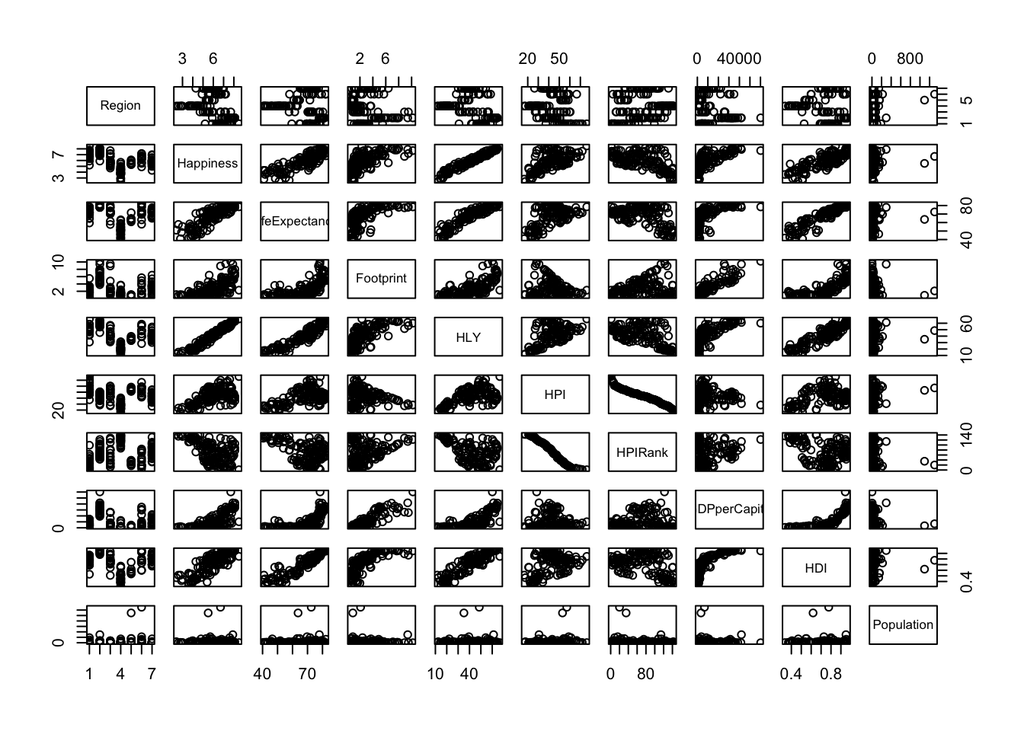

```r
plot(HappyPlanetIndex[-1])
```

It looks like `HLY` has very strong linear association with `Happiness`–however, calculating HLY involves a 1-10 happiness score, so `HLY` is, by definition, dependent on `Happiness` (see [the Happy Planet Index website](http://www.happyplanetindex.org/about/)). So, that’s not very interesting. However, it looks like `HDI` (Human Development Index), which does not directly depend on `Happiness` also has a strong linear association. We’ll choose this as our explanatory variable.

Although we’ve seen a small plot of it on our scatterplot matrix, let’s plot `HDI` and `Happiness` together on a larger scale. Because we expect that we’ll add a linear model soon, we’ll use `ggplot2`. If you didn’t remove the rows with missing values, you’ll get a message from R saying that it’s been done automatically.

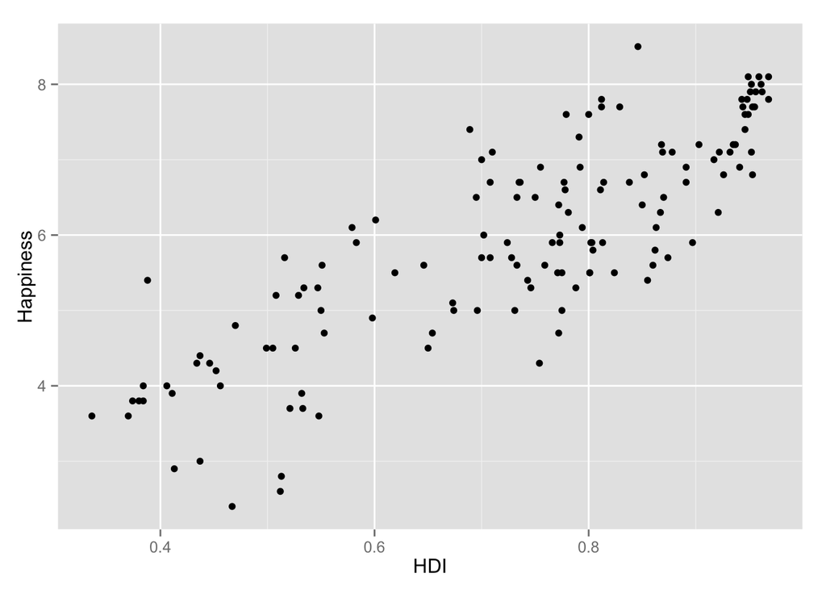

```r
ggplot(HappyPlanetIndex, aes(x=HDI, y=Happiness)) +geom_point()
```

## Linear Model

Now we’ll define our linear model and look at the summary.

```r
lm(Happiness~HDI, data=HappyPlanetIndex)
```

```
##
## Call:
## lm(formula = Happiness ~ HDI, data = HappyPlanetIndex)
##
## Coefficients:
## (Intercept)          HDI
##       1.168        6.521
```

```r
summary(lm(Happiness~HDI, data=HappyPlanetIndex))
```

```
##
## Call:
## lm(formula = Happiness ~ HDI, data = HappyPlanetIndex)
##
## Residuals:
##      Min       1Q   Median       3Q      Max
## -1.90651 -0.52154  0.06757  0.48284  1.81540
##
## Coefficients:
##             Estimate Std. Error t value Pr(>|t|)
## (Intercept)   1.1676     0.2728   4.281 3.45e-05 ***
## HDI           6.5212     0.3636  17.934  < 2e-16 ***
## ---
## Signif. codes:  0 '***' 0.001 '**' 0.01 '*' 0.05 '.' 0.1 ' ' 1
##
## Residual standard error: 0.7621 on 139 degrees of freedom
##   (2 observations deleted due to missingness)
## Multiple R-squared:  0.6982, Adjusted R-squared:  0.6961
## F-statistic: 321.6 on 1 and 139 DF,  p-value: < 2.2e-16
```

We’ll also superimpose our linear model onto our scatterplot.

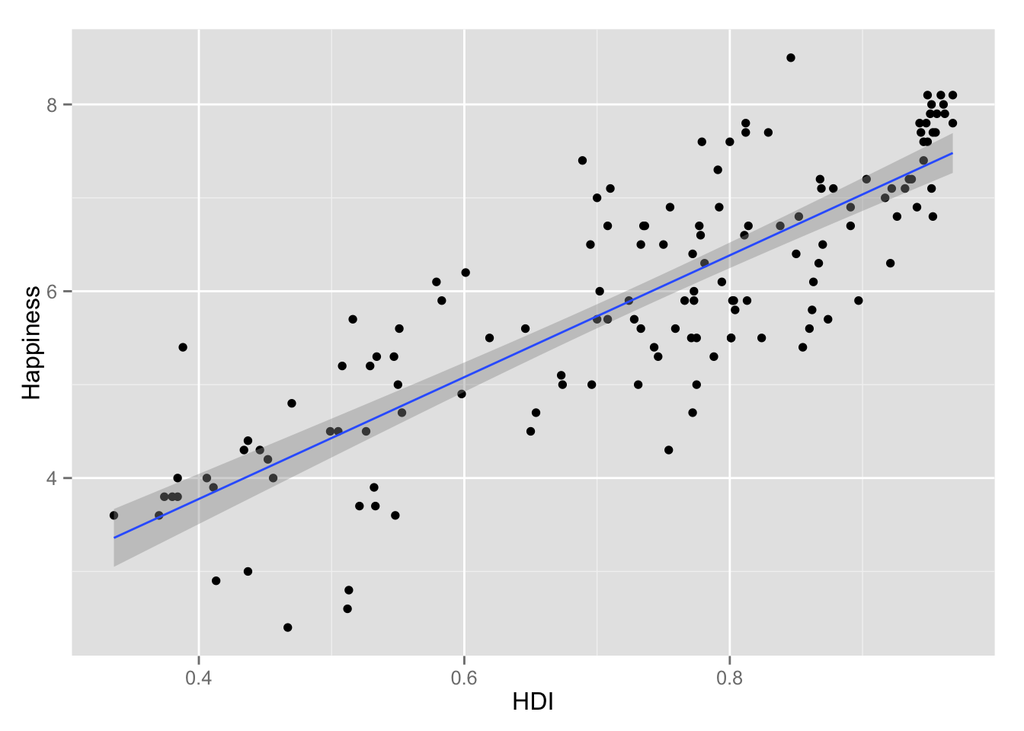

```r
ggplot(HappyPlanetIndex, aes(x=HDI, y=Happiness)) +geom_point() + stat_smooth(method="lm")
```

## Permutation for Regression

First, we need to pick a statistic to permute. Your two basic options here are slope and correlation. Because the methods are different, we’ll look at the initial steps for both slope and correlation.

### One Sample

#### Slope

Just as we did for permutation tests, we permute the sample by shuffling one of the groups–in this case, `HDI`. Here’s how it looks for one permutation:

```r
lm(Happiness~shuffle(HDI), data=HappyPlanetIndex)
```

```
##
## Call:
## lm(formula = Happiness ~ shuffle(HDI), data = HappyPlanetIndex)
##
## Coefficients:
##  (Intercept)  shuffle(HDI)
##       6.1037       -0.2288
```

If you try this multiple times, you will get different results depending on how `HDI` was shuffled. However, we only need the slope, not the y-intercept.

Let’s look at the structure of a linear model. There’s quite a bit there.

```r
str(lm(Happiness~shuffle(HDI), data=HappyPlanetIndex))
```

```
## List of 13
##  $ coefficients : Named num [1:2] 5.785 0.185
##   ..- attr(*, "names")= chr [1:2] "(Intercept)" "shuffle(HDI)"
##  $ residuals    : Named num [1:141] -0.347 -0.267 -1.612 1.145 -0.92 ...
##   ..- attr(*, "names")= chr [1:141] "1" "2" "3" "4" ...
##  $ effects      : Named num [1:141] -70.286 0.387 -1.584 1.149 -0.896 ...
##   ..- attr(*, "names")= chr [1:141] "(Intercept)" "shuffle(HDI)" "" "" ...
##  $ rank         : int 2
##  $ fitted.values: Named num [1:141] 5.85 5.87 5.91 5.95 5.92 ...
##   ..- attr(*, "names")= chr [1:141] "1" "2" "3" "4" ...
##  $ assign       : int [1:2] 0 1
##  $ qr           :List of 5
##   ..$ qr   : num [1:141, 1:2] -11.8743 0.0842 0.0842 0.0842 0.0842 ...
##   .. ..- attr(*, "dimnames")=List of 2
##   .. .. ..$ : chr [1:141] "1" "2" "3" "4" ...
##   .. .. ..$ : chr [1:2] "(Intercept)" "shuffle(HDI)"
##   .. ..- attr(*, "assign")= int [1:2] 0 1
##   ..$ qraux: num [1:2] 1.08 1.12
##   ..$ pivot: int [1:2] 1 2
##   ..$ tol  : num 1e-07
##   ..$ rank : int 2
##   ..- attr(*, "class")= chr "qr"
##  $ df.residual  : int 139
##  $ na.action    :Class 'omit'  Named int [1:2] 19 72
##   .. ..- attr(*, "names")= chr [1:2] "19" "72"
##  $ xlevels      : Named list()
##  $ call         : language lm(formula = Happiness ~ shuffle(HDI), data = HappyPlanetIndex)
##  $ terms        :Classes 'terms', 'formula' length 3 Happiness ~ shuffle(HDI)
##   .. ..- attr(*, "variables")= language list(Happiness, shuffle(HDI))
##   .. ..- attr(*, "factors")= int [1:2, 1] 0 1
##   .. .. ..- attr(*, "dimnames")=List of 2
##   .. .. .. ..$ : chr [1:2] "Happiness" "shuffle(HDI)"
##   .. .. .. ..$ : chr "shuffle(HDI)"
##   .. ..- attr(*, "term.labels")= chr "shuffle(HDI)"
##   .. ..- attr(*, "order")= int 1
##   .. ..- attr(*, "intercept")= int 1
##   .. ..- attr(*, "response")= int 1
##   .. ..- attr(*, ".Environment")=<environment: R_GlobalEnv>
##   .. ..- attr(*, "predvars")= language list(Happiness, shuffle(HDI))
##   .. ..- attr(*, "dataClasses")= Named chr [1:2] "numeric" "numeric"
##   .. .. ..- attr(*, "names")= chr [1:2] "Happiness" "shuffle(HDI)"
##  $ model        :'data.frame':   141 obs. of  2 variables:
##   ..$ Happiness   : num [1:141] 5.5 5.6 4.3 7.1 5 7.9 7.8 5.3 5.3 5.8 ...
##   ..$ shuffle(HDI): num [1:141] 0.336 0.446 0.689 0.922 0.733 0.956 0.867 0.521 0.946 0.846 ...
##   ..- attr(*, "terms")=Classes 'terms', 'formula' length 3 Happiness ~ shuffle(HDI)
##   .. .. ..- attr(*, "variables")= language list(Happiness, shuffle(HDI))
##   .. .. ..- attr(*, "factors")= int [1:2, 1] 0 1
##   .. .. .. ..- attr(*, "dimnames")=List of 2
##   .. .. .. .. ..$ : chr [1:2] "Happiness" "shuffle(HDI)"
##   .. .. .. .. ..$ : chr "shuffle(HDI)"
##   .. .. ..- attr(*, "term.labels")= chr "shuffle(HDI)"
##   .. .. ..- attr(*, "order")= int 1
##   .. .. ..- attr(*, "intercept")= int 1
##   .. .. ..- attr(*, "response")= int 1
##   .. .. ..- attr(*, ".Environment")=<environment: R_GlobalEnv>
##   .. .. ..- attr(*, "predvars")= language list(Happiness, shuffle(HDI))
##   .. .. ..- attr(*, "dataClasses")= Named chr [1:2] "numeric" "numeric"
##   .. .. .. ..- attr(*, "names")= chr [1:2] "Happiness" "shuffle(HDI)"
##   ..- attr(*, "na.action")=Class 'omit'  Named int [1:2] 19 72
##   .. .. ..- attr(*, "names")= chr [1:2] "19" "72"
##  - attr(*, "class")= chr "lm"
```

Anything that’s preceded by a dollar sign, we can directly subset.

```r
lm(Happiness~shuffle(HDI), data=HappyPlanetIndex)$coefficients
```

```
##  (Intercept) shuffle(HDI)
##    5.6769540    0.3545773
```

Now we can pull off just the slope. The slope below may differ from the one above, because it’s shuffling the data in a different way.

```r
lm(Happiness~shuffle(HDI), data=HappyPlanetIndex)$coefficients[2]
```

```
## shuffle(HDI)
##    0.3608107
```

We can do this many times for our permutation distribution.

#### Correlation

```r
cor(HappyPlanetIndex$HDI, sample(HappyPlanetIndex$Happiness), use="complete.obs")
```

```
## [1] 0.1322561
```

We can do this many times for our permutation distribution.

### Many Permutations

We’ll just permute for slope here. We’ll create a list of data called `perms` that contains 1,000 slopes of linear models where `Happiness` depends on shuffled `HDI` scores. Then we’ll make a data frame called `trials` that is a data frame of `perms`, with a column named `perms`.

```r
perms <-do (1000) * lm(Happiness~shuffle(HDI), data=HappyPlanetIndex)$coefficients[2]
trials <- data.frame(perms)
names(trials) <- "perms"
head(trials)
```

```
##         perms
## 1  1.33308791
## 2 -0.28971962
## 3 -1.26336403
## 4 -0.07948269
## 5 -0.38540006
## 6 -0.13043081
```

### Plots

```r
favstats(perms, data=trials)
```

```
##     min         Q1    median        Q3      max        mean        sd    n
##  -2.084 -0.4263475 0.0156078 0.4380288 2.078085 0.008212663 0.6588478 1000
##  missing
##        0
```

We’ll use `ggplot2` graphics here. We don’t need to use facetting because the dataset has already been broken down into mean differences.

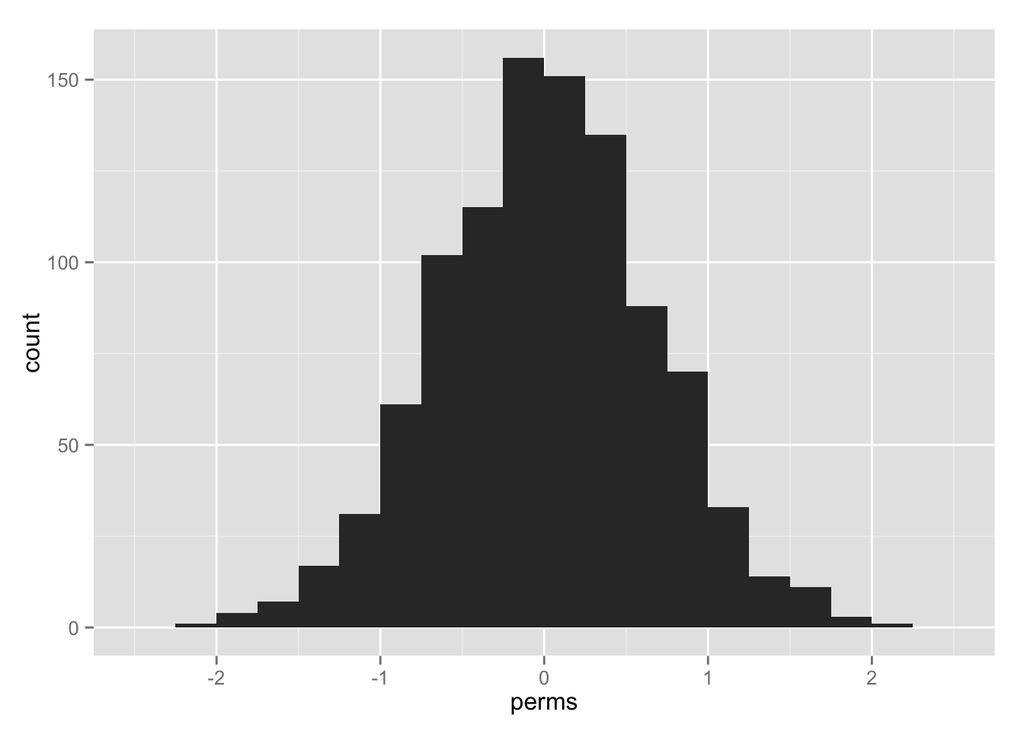

```r
ggplot(trials, aes(x=perms)) + geom_histogram(binwidth=0.25)
```

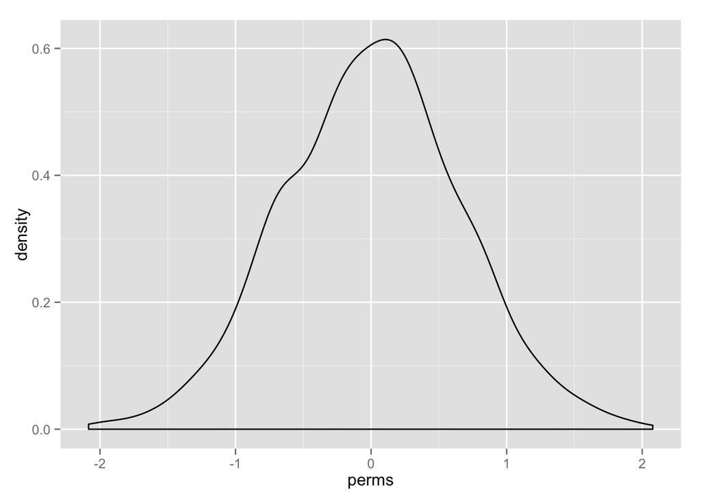

```r
ggplot(trials, aes(x=perms)) + geom_density()
```

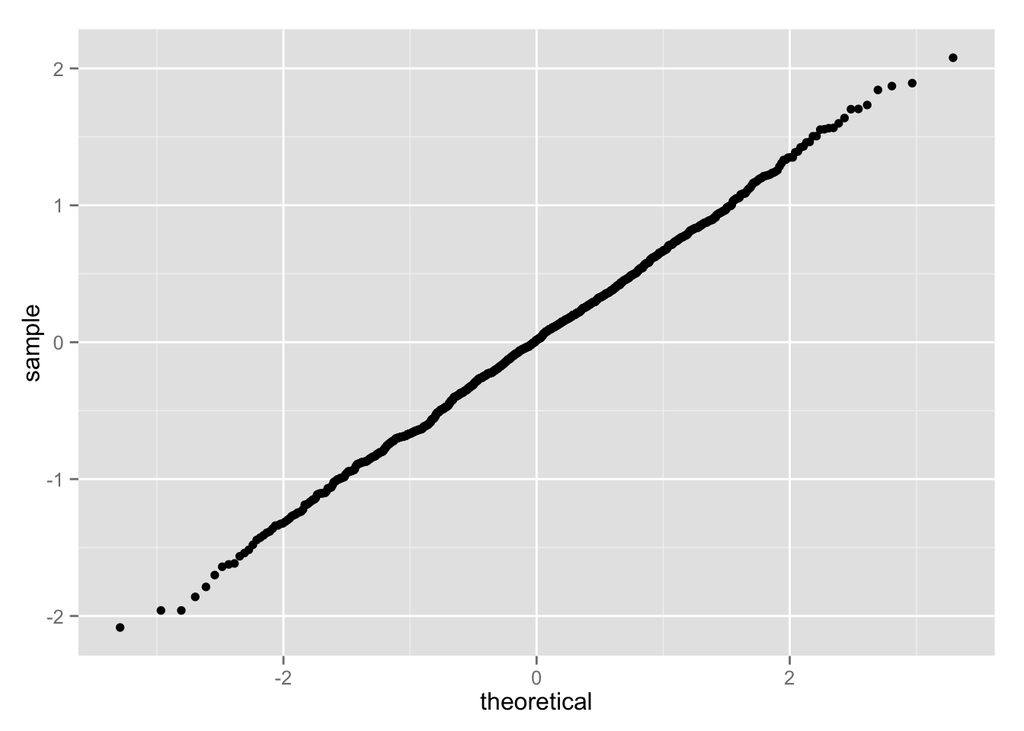

```r
ggplot(trials, aes(sample=perms)) + stat_qq()
```

## P-Value

We will calculate p-values with the null hypothesis that the slope is equal to 0. We will also need the observed slope of our original, unshuffled linear model.

```r
slope <- lm(Happiness~HDI, data=HappyPlanetIndex)$coefficients[2]
n <- 1000
```

### Lower Tail

Lower tail p-values are calculated as the proportion of trial slopes that were less than or equal to the observed slope. We add one to both the numerator and denominator to include the original sample.

```r
lt <- (sum(trials$perms <= slope) +1)/(n+1)
signif(lt, digits=3)
```

```
## [1] 1
```

### Upper Tail

Upper tail p-values are calculated as the proportion of trial slopes that were greater than or equal to the observed slope. We add one to both the numerator and denominator to include the original sample.

```r
ut <- (sum(trials$perms >= slope) +1)/(n+1)
ut
```

```
## [1] 0.000999001
```

### Two-Tailed

Two-tailed p-values are usually defined as the smaller of the lower and upper tailed tests, multiplied by two.

```r
(tt <- min(lt, ut)*2)
```

```
## [1] 0.001998002
```